# 2017 EPA draft NEI vs DNREC estimates

Shane Cone

1/7/2020

# Purpose

The purpose of this analysis is to examine the EPA 2017 NEI for the nonpoint sector.

- First, to see if they are using the estimates we gave them (they are)
- Second, to see what they are adding outside of the estimates we provided

To do this, I am comparing the different datasets which are stored in EIS.

```r
knitr::opts_chunk$set(echo = FALSE)
```

# Comparing EPA to DE estimates

```
## # A tibble: 45 x 15
##    state `fips state cod~ `tribal name` `fips code` county `data category`
##    <chr>            <dbl> <lgl>               <dbl> <chr>  <chr>
##  1 DE                  10 NA                  10001 Kent   NP
##  2 DE                  10 NA                  10001 Kent   NP
##  3 DE                  10 NA                  10003 New C~ NP
##  4 DE                  10 NA                  10005 Sussex NP
##  5 DE                  10 NA                  10001 Kent   NP
##  6 DE                  10 NA                  10003 New C~ NP
##  7 DE                  10 NA                  10003 New C~ NP
##  8 DE                  10 NA                  10003 New C~ NP
##  9 DE                  10 NA                  10005 Sussex NP
## 10 DE                  10 NA                  10001 Kent   NP
## # ... with 35 more rows, and 9 more variables: `emissions type
## #   code` <lgl>, scc <dbl>, `reporting period` <chr>, `emissions operating
## #   type` <chr>, `pollutant code` <chr>, `pollutant desc` <chr>, `total
## #   emissions` <dbl>, `emissions uom` <chr>, `data set` <chr>
```

```
## # A tibble: 0 x 6
## # Groups:   fips code, scc, pollutant code [0]
## # ... with 6 variables: `fips code` <dbl>, scc <dbl>, `pollutant
## #   code` <chr>, `data set` <chr>, Emissions <dbl>, cond <lgl>
```

Zero rows are returned by the above code block. This means that there are no records where we submitted data (2017 DEDNR) where the EPA estimates (2017NEI_Dec2019) are different. This is good, as it shows that EPA is not creating or using estimates which are different from our own.

# Checking EPA estimates where we did not submit estimates

```
## # A tibble: 136 x 6
## # Groups:   fips code, scc, pollutant code [136]
##    `fips code`        scc `pollutant code` `data set`      Emissions count
##          <dbl>      <dbl> <chr>            <chr>               <dbl> <int>
##  1       10003   20100901 NH3              2017NEI_Dec2019     44.5      1
##  2       10003   30101816 PM10-FIL         2017NEI_Dec2019      6.72     1
##  3       10003   30101816 PM25-FIL         2017NEI_Dec2019      6.72     1
##  4       10003 2104008100 CO               2017NEI_Dec2019    410.       1
##  5       10003 2104008100 NH3              2017NEI_Dec2019      4.95     1
##  6       10003 2104008100 NOX              2017NEI_Dec2019      7.15     1
##  7       10003 2104008100 PM10-PRI         2017NEI_Dec2019     64.9      1
##  8       10003 2104008100 PM25-PRI         2017NEI_Dec2019     64.9      1
##  9       10003 2104008100 SO2              2017NEI_Dec2019      1.10     1
## 10       10003 2104008100 VOC              2017NEI_Dec2019     52.0      1
## # ... with 126 more rows
```

This output has 136 rows, showing that there are 136 entries where EPA has estimated emissions where we did not provide any.

Examining them further, we see their distribution by SCC Tier level 3 descriptions

| tier 3 description | count |
| --- | --- |
| Agricultural Crops | 4 |
| Agricultural Fires | 2 |
| Agricultural Livestock | 1 |
| Commercial Cooking | 15 |
| Construction | 6 |
| Fireplaces | 7 |
| Other | 59 |
| Pesticide Application | 1 |
| Wastewater Treatment | 1 |
| Woodstoves | 38 |
| Yard Waste | 2 |

Woodstoves and commercial cooking were categories we outright elected to let EPA estimate.

Now lets look at all the rest in more detail

| fips code | scc | pollutant code | data set | Emissions | count | data category | sector | tier 1 description | tier 2 description | tier 3 description |
| --- | --- | --- | --- | --- | --- | --- | --- | --- | --- | --- |
| 10003 | 2311010000 | PM10-FIL | 2017NEI_Dec2019 | 66.500000 | 1 | Nonpoint | Dust - Construction Dust | Miscellaneous | Other Fugitive Dust | Construction |
| 10003 | 2311010000 | PM25-FIL | 2017NEI_Dec2019 | 6.650000 | 1 | Nonpoint | Dust - Construction Dust | Miscellaneous | Other Fugitive Dust | Construction |
| 10003 | 2311020000 | PM10-FIL | 2017NEI_Dec2019 | 827.660000 | 1 | Nonpoint | Dust - Construction Dust | Miscellaneous | Other Fugitive Dust | Construction |
| 10003 | 2311020000 | PM25-FIL | 2017NEI_Dec2019 | 82.760000 | 1 | Nonpoint | Dust - Construction Dust | Miscellaneous | Other Fugitive Dust | Construction |
| 10003 | 2311030000 | PM10-FIL | 2017NEI_Dec2019 | 3709.240000 | 1 | Nonpoint | Dust - Construction Dust | Miscellaneous | Other Fugitive Dust | Construction |
| 10003 | 2311030000 | PM25-FIL | 2017NEI_Dec2019 | 370.920000 | 1 | Nonpoint | Dust - Construction Dust | Miscellaneous | Other Fugitive Dust | Construction |
| 10003 | 2461850000 | VOC | 2017NEI_Dec2019 | 30.404940 | 1 | Nonpoint | Solvent - Consumer & Commercial Solvent Use | Solvent Utilization | Nonindustrial | Pesticide Application |
| 10003 | 2610000400 | PM10-FIL | 2017NEI_Dec2019 | 1.820000 | 1 | Nonpoint | Waste Disposal | Waste Disposal & Recycling | Open Burning | Yard Waste |
| 10003 | 2610000400 | PM25-FIL | 2017NEI_Dec2019 | 1.400000 | 1 | Nonpoint | Waste Disposal | Waste Disposal & Recycling | Open Burning | Yard Waste |
| 10003 | 2630020000 | VOC | 2017NEI_Dec2019 | 11.584270 | 1 | Nonpoint | Waste Disposal | Waste Disposal & Recycling | POTW | Wastewater Treatment |
| 10003 | 2680003000 | NH3 | 2017NEI_Dec2019 | 26.348210 | 1 | Nonpoint | Waste Disposal | Waste Disposal & Recycling | Other | Other |
| 10003 | 2680003000 | VOC | 2017NEI_Dec2019 | 186.433600 | 1 | Nonpoint | Waste Disposal | Waste Disposal & Recycling | Other | Other |
| 10003 | 2801000003 | PM10-FIL | 2017NEI_Dec2019 | 35.940000 | 1 | Nonpoint | Agriculture - Crops & Livestock Dust | Miscellaneous | Agriculture & Forestry | Agricultural Crops |
| 10003 | 2801000003 | PM25-FIL | 2017NEI_Dec2019 | 5.380000 | 1 | Nonpoint | Agriculture - Crops & Livestock Dust | Miscellaneous | Agriculture & Forestry | Agricultural Crops |
| 10003 | 2801000005 | PM10-FIL | 2017NEI_Dec2019 | 96.010000 | 1 | Nonpoint | Agriculture - Crops & Livestock Dust | Miscellaneous | Agriculture & Forestry | Agricultural Crops |
| 10003 | 2801000005 | PM25-FIL | 2017NEI_Dec2019 | 14.390000 | 1 | Nonpoint | Agriculture - Crops & Livestock Dust | Miscellaneous | Agriculture & Forestry | Agricultural Crops |
| 10003 | 2801500141 | CO | 2017NEI_Dec2019 | 4.790000 | 1 | Nonpoint | Fires - Agricultural Field Burning | Miscellaneous | Other Combustion | Agricultural Fires |
| 10003 | 2801500141 | NH3 | 2017NEI_Dec2019 | 1.690000 | 1 | Nonpoint | Fires - Agricultural Field Burning | Miscellaneous | Other Combustion | Agricultural Fires |
| 10003 | 2805002000 | NH3 | 2017NEI_Dec2019 | 4.882393 | 1 | Nonpoint | Agriculture - Livestock Waste | Miscellaneous | Agriculture & Forestry | Agricultural Livestock |
| 10003 | 2810025000 | CO | 2017NEI_Dec2019 | 150.040300 | 1 | Nonpoint | Miscellaneous Non-Industrial NEC | Other Industrial Processes | Agriculture, Food, & Kindred Products | Other |
| 10003 | 2810025000 | NOX | 2017NEI_Dec2019 | 3.102727 | 1 | Nonpoint | Miscellaneous Non-Industrial NEC | Other Industrial Processes | Agriculture, Food, & Kindred Products | Other |
| 10003 | 2810025000 | PM10-PRI | 2017NEI_Dec2019 | 28.456900 | 1 | Nonpoint | Miscellaneous Non-Industrial NEC | Other Industrial Processes | Agriculture, Food, & Kindred Products | Other |
| 10003 | 2810025000 | PM25-PRI | 2017NEI_Dec2019 | 22.778030 | 1 | Nonpoint | Miscellaneous Non-Industrial NEC | Other Industrial Processes | Agriculture, Food, & Kindred Products | Other |
| 10003 | 2810025000 | VOC | 2017NEI_Dec2019 | 8.226359 | 1 | Nonpoint | Miscellaneous Non-Industrial NEC | Other Industrial Processes | Agriculture, Food, & Kindred Products | Other |
| 10003 | 2810050000 | PM10-FIL | 2017NEI_Dec2019 | 2.460000 | 1 | Nonpoint | Miscellaneous Non-Industrial NEC | Miscellaneous | Other Combustion | Other |
| 10003 | 2810050000 | PM25-FIL | 2017NEI_Dec2019 | 2.460000 | 1 | Nonpoint | Miscellaneous Non-Industrial NEC | Miscellaneous | Other Combustion | Other |

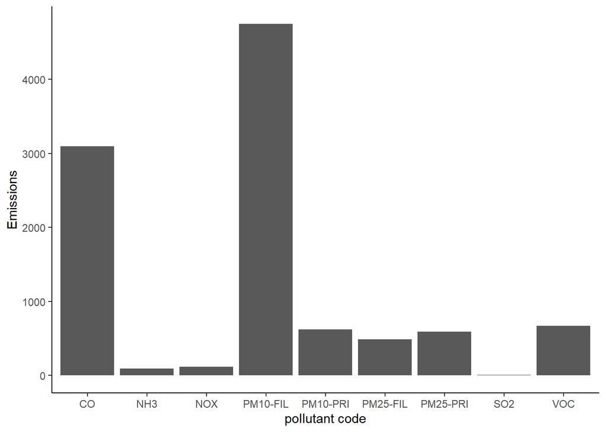

# Dust from Hooves

We also needed to see what EPA would estimate for us for Hooves from Dust (a category we have not, in the past, estimated ourselves)

| data set | n |
| --- | --- |
| 2017EPA_NONPOINT | 72 |
| 2017EPA_NONPOINT_dra | 12 |

| data set | pollutant code | emissions |
| --- | --- | --- |
| 2017EPA_NONPOINT | PM10-FIL | 1294.1294 |
| 2017EPA_NONPOINT | PM10-PRI | 1294.1294 |
| 2017EPA_NONPOINT | PM25-FIL | 128.0552 |
| 2017EPA_NONPOINT | PM25-PRI | 128.0552 |
| 2017EPA_NONPOINT_dra | PM10-FIL | 1294.1294 |
| 2017EPA_NONPOINT_dra | PM10-PRI | 1294.1294 |
| 2017EPA_NONPOINT_dra | PM25-FIL | 128.0552 |
| 2017EPA_NONPOINT_dra | PM25-PRI | 128.0552 |

The takeaways from dust: the two epa estimates are consistent with each other. The total PM 10 would be ~1300 tons, and for PM2.5 would be ~128 tons. By my first-order estimate, the dust from hooves would be much higher ~several thousand tons of PM10), but the bulk of that is from Broilers, and the emission factor is likely not representative for Delaware.